# Exploratory Data Analysis

EDA ON TITATIC DATASET FOR SURVIVOR PREDICTION

#### Data Preprocessing

1.Load data 2.Data Overview

#### Data Cleaning

1.Handling Null values 2.Handling Outliers

#### Data Analysis

1.Univariate Analysis 2.Multivariate Analysis

#### Feature Engineering

1.Creating new columns 2.Modifying columns

```python
import pandas as pd
import numpy as np
import matplotlib.pyplot as plt
import seaborn as sns
```

```python
df2 = pd.read_csv('D:\\EDA project1\\Titanic.csv')
df2
```

|  | pclass | survived | name | sex | age | sibsp | parch | ticket | fare | cabin | embarked | boat | body | home.dest |
| --- | --- | --- | --- | --- | --- | --- | --- | --- | --- | --- | --- | --- | --- | --- |
| 0 | 1.0 | 1.0 | Allen, Miss. Elisabeth Walton | female | 29.0000 | 0.0 | 0.0 | 24160 | 211.3375 | B5 | S | 2 | NaN | St Louis, MO |
| 1 | 1.0 | 1.0 | Allison, Master. Hudson Trevor | male | 0.9167 | 1.0 | 2.0 | 113781 | 151.5500 | C22 C26 | S | 11 | NaN | Montreal, PQ / Chesterville, ON |
| 2 | 1.0 | 0.0 | Allison, Miss. Helen Loraine | female | 2.0000 | 1.0 | 2.0 | 113781 | 151.5500 | C22 C26 | S | NaN | NaN | Montreal, PQ / Chesterville, ON |
| 3 | 1.0 | 0.0 | Allison, Mr. Hudson Joshua Creighton | male | 30.0000 | 1.0 | 2.0 | 113781 | 151.5500 | C22 C26 | S | NaN | 135.0 | Montreal, PQ / Chesterville, ON |
| 4 | 1.0 | 0.0 | Allison, Mrs. Hudson J C (Bessie Waldo Daniels) | female | 25.0000 | 1.0 | 2.0 | 113781 | 151.5500 | C22 C26 | S | NaN | NaN | Montreal, PQ / Chesterville, ON |
| ... | ... | ... | ... | ... | ... | ... | ... | ... | ... | ... | ... | ... | ... | ... |
| 1305 | 3.0 | 0.0 | Zabour, Miss. Thamine | female | NaN | 1.0 | 0.0 | 2665 | 14.4542 | NaN | C | NaN | NaN | NaN |
| 1306 | 3.0 | 0.0 | Zakarian, Mr. Mapriededer | male | 26.5000 | 0.0 | 0.0 | 2656 | 7.2250 | NaN | C | NaN | 304.0 | NaN |
| 1307 | 3.0 | 0.0 | Zakarian, Mr. Ortin | male | 27.0000 | 0.0 | 0.0 | 2670 | 7.2250 | NaN | C | NaN | NaN | NaN |
| 1308 | 3.0 | 0.0 | Zimmerman, Mr. Leo | male | 29.0000 | 0.0 | 0.0 | 315082 | 7.8750 | NaN | S | NaN | NaN | NaN |
| 1309 | NaN | NaN | NaN | NaN | NaN | NaN | NaN | NaN | NaN | NaN | NaN | NaN | NaN | NaN |

1310 rows × 14 columns

```python
# Get the shape of the DataFrame
df2.shape
#df2.shape[0] = 1310  # df2.shape[1]= 14
```

```
(1310, 14)
```

```python
# Display the first two rows of the DataFrame df2
df2.head(2)
```

|  | pclass | survived | name | sex | age | sibsp | parch | ticket | fare | cabin | embarked | boat | body | home.dest |
| --- | --- | --- | --- | --- | --- | --- | --- | --- | --- | --- | --- | --- | --- | --- |
| 0 | 1.0 | 1.0 | Allen, Miss. Elisabeth Walton | female | 29.0000 | 0.0 | 0.0 | 24160 | 211.3375 | B5 | S | 2 | NaN | St Louis, MO |
| 1 | 1.0 | 1.0 | Allison, Master. Hudson Trevor | male | 0.9167 | 1.0 | 2.0 | 113781 | 151.5500 | C22 C26 | S | 11 | NaN | Montreal, PQ / Chesterville, ON |

```python
# Display the last 3 rows of the DataFrame df2
df2.tail(3)
```

|  | pclass | survived | name | sex | age | sibsp | parch | ticket | fare | cabin | embarked | boat | body | home.dest |
| --- | --- | --- | --- | --- | --- | --- | --- | --- | --- | --- | --- | --- | --- | --- |
| 1307 | 3.0 | 0.0 | Zakarian, Mr. Ortin | male | 27.0 | 0.0 | 0.0 | 2670 | 7.225 | NaN | C | NaN | NaN | NaN |
| 1308 | 3.0 | 0.0 | Zimmerman, Mr. Leo | male | 29.0 | 0.0 | 0.0 | 315082 | 7.875 | NaN | S | NaN | NaN | NaN |
| 1309 | NaN | NaN | NaN | NaN | NaN | NaN | NaN | NaN | NaN | NaN | NaN | NaN | NaN | NaN |

```python
# to get information about the dataframe
df2.info()
```

```
<class 'pandas.core.frame.DataFrame'>
RangeIndex: 1310 entries, 0 to 1309
Data columns (total 14 columns):
 #   Column     Non-Null Count  Dtype
---  ------     --------------  -----
 0   pclass     1309 non-null   float64
 1   survived   1309 non-null   float64
 2   name       1309 non-null   object
 3   sex        1309 non-null   object
 4   age        1046 non-null   float64
 5   sibsp      1309 non-null   float64
 6   parch      1309 non-null   float64
 7   ticket     1309 non-null   object
 8   fare       1308 non-null   float64
 9   cabin      295 non-null    object
 10  embarked   1307 non-null   object
 11  boat       486 non-null    object
 12  body       121 non-null    float64
 13  home.dest  745 non-null    object
dtypes: float64(7), object(7)
memory usage: 143.4+ KB
```

```python
# descriptive statistics of the DataFrame
df2.describe()
```

|  | pclass | survived | age | sibsp | parch | fare | body |
| --- | --- | --- | --- | --- | --- | --- | --- |
| count | 1309.000000 | 1309.000000 | 1046.000000 | 1309.000000 | 1309.000000 | 1308.000000 | 121.000000 |
| mean | 2.294882 | 0.381971 | 29.881135 | 0.498854 | 0.385027 | 33.295479 | 160.809917 |
| std | 0.837836 | 0.486055 | 14.413500 | 1.041658 | 0.865560 | 51.758668 | 97.696922 |
| min | 1.000000 | 0.000000 | 0.166700 | 0.000000 | 0.000000 | 0.000000 | 1.000000 |
| 25% | 2.000000 | 0.000000 | 21.000000 | 0.000000 | 0.000000 | 7.895800 | 72.000000 |
| 50% | 3.000000 | 0.000000 | 28.000000 | 0.000000 | 0.000000 | 14.454200 | 155.000000 |
| 75% | 3.000000 | 1.000000 | 39.000000 | 1.000000 | 0.000000 | 31.275000 | 256.000000 |
| max | 3.000000 | 1.000000 | 80.000000 | 8.000000 | 9.000000 | 512.329200 | 328.000000 |

```python
# Check the number of null values in df2
df2.isnull().sum()
```

```
pclass          1
survived        1
name            1
sex             1
age           264
sibsp           1
parch           1
ticket          1
fare            2
cabin        1015
embarked        3
boat          824
body         1189
home.dest     565
dtype: int64
```

#### Treating null values...> Rules:

1.null values greater than 40% --> the column will be dropped 2.null values will be less than 5%--> we can drop the null values 3.null values will be between 5 to 40-->#replace the values with either mean / median (depending on presence of outliers)

```python
#Get the column names of a DataFrame
df2.columns
```

```
Index(['pclass', 'survived', 'name', 'sex', 'age', 'sibsp', 'parch', 'ticket',
       'fare', 'cabin', 'embarked', 'boat', 'body', 'home.dest'],
      dtype='object')
```

```python
n = df2.shape[0]

drop_clm = []
drop_na = []
fill_na = []

# Loop through each column in df2
for i in df2.columns:
    x = df2[i].isnull().sum()

    # Check if the percentage of null values is greater than or equal to 40%
    if (x / n * 100) >= 40:
        drop_clm.append(i)

    # Check if the percentage of null values is less than or equal to 5%
    elif (x / n * 100) <= 5:
        drop_na.append(i)

    # Otherwise, add the column to fill_na list
    else:
        fill_na.append(i)

drop_clm
```

```
['cabin', 'boat', 'body', 'home.dest']
```

```python
fill_na
```

```
['age']
```

```python
drop_na
```

```
['pclass',
 'survived',
 'name',
 'sex',
 'sibsp',
 'parch',
 'ticket',
 'fare',
 'embarked']
```

```python
# Remove drop_clm list columns from df2
df2.drop(drop_clm,axis=1, inplace = True)
```

```python
df2.columns
```

```
Index(['pclass', 'survived', 'name', 'sex', 'age', 'sibsp', 'parch', 'ticket',
       'fare', 'embarked'],
      dtype='object')
```

```python
# Again calculate the percentage of missing values in each column of df2
n=df2.shape[0]
for i in df2.columns:
    x=df2[i].isnull().sum()
    print(i,(x/n)*100)
```

```
pclass 0.07633587786259542
survived 0.07633587786259542
name 0.07633587786259542
sex 0.07633587786259542
age 20.15267175572519
sibsp 0.07633587786259542
parch 0.07633587786259542
ticket 0.07633587786259542
fare 0.15267175572519084
embarked 0.22900763358778628
```

```python
#filling missing values

df2["age"]=df2['age'].fillna(df2.age.median())
df2.age.isnull().sum()
```

```
0
```

```python
df2["embarked"] = df2.embarked.fillna(df2.embarked.mode)
df2.embarked.isnull().sum()
```

```
0
```

```python
df2.dropna(inplace=True)
df2.isnull().sum()
```

```
pclass      0
survived    0
name        0
sex         0
age         0
sibsp       0
parch       0
ticket      0
fare        0
embarked    0
dtype: int64
```

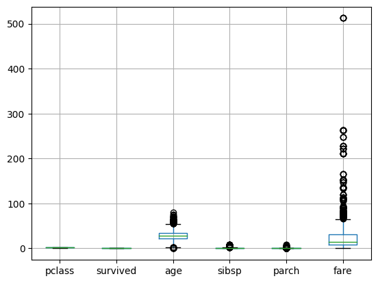

```python
# Display a boxplot
df2.boxplot()
```

Box plot is showing column “age” and “fare” is having outliers.

Treating outliers:

# whether the data type of column is numerical or object.

# age is having outliers ,,fill the missing values with median else mean